# Module 1: Additional Data Examples

Hyunseung Kang

9/14/2020

# Overview

This document provides additional data that you can use to test our your code. These data looks at outbound network traffic for specific ip addresses from my local router on September 7, 2020. While it is not server data, the data below closely mimics the type of server analytic data for module 1.

## Example 1: Youtube Internet Traffic From My Router

$y_t$ is measured in kilobytes and represents the cumulative outbound traffic. $t$ is measured in seconds and spans from 1 to 1000. In the plot below, I’ve set the maxcap to $100 \cdot 10^3$ and the router hit that limit at $t = 1501$. Obviously, you want to aim below that (but not by too much) as overshooting the time would be much worse than undershooting it.

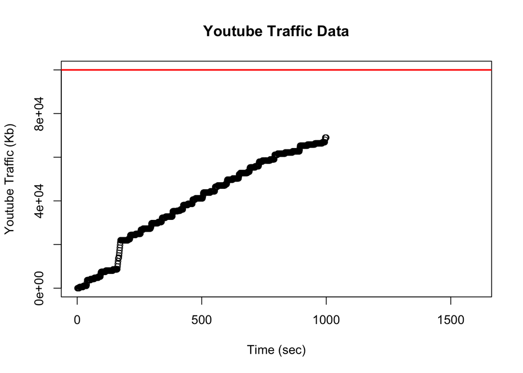

```r
maxcap = 100*10^3;
out_data = read.csv("out_youtube.csv",header=TRUE)
plot(out_data$t,out_data$y_t,ylim=c(0,maxcap),xlim=c(0,1600),
     ylab="Youtube Traffic (Kb)",xlab="Time (sec)",main="Youtube Traffic Data")
abline(h = maxcap,col="red",lwd=2)
```

## Example 2: Box Sync Data

Again, $y_t$ is measured in kilobytes and represents the cumulative traffic. $t$ is measured in seconds and spans from 1 to 306. In the plot below, I’ve set the maxcap to $100$ and I would say that good timepoint to alert the engineer of hard drive capacity is slightly below 300-ish.

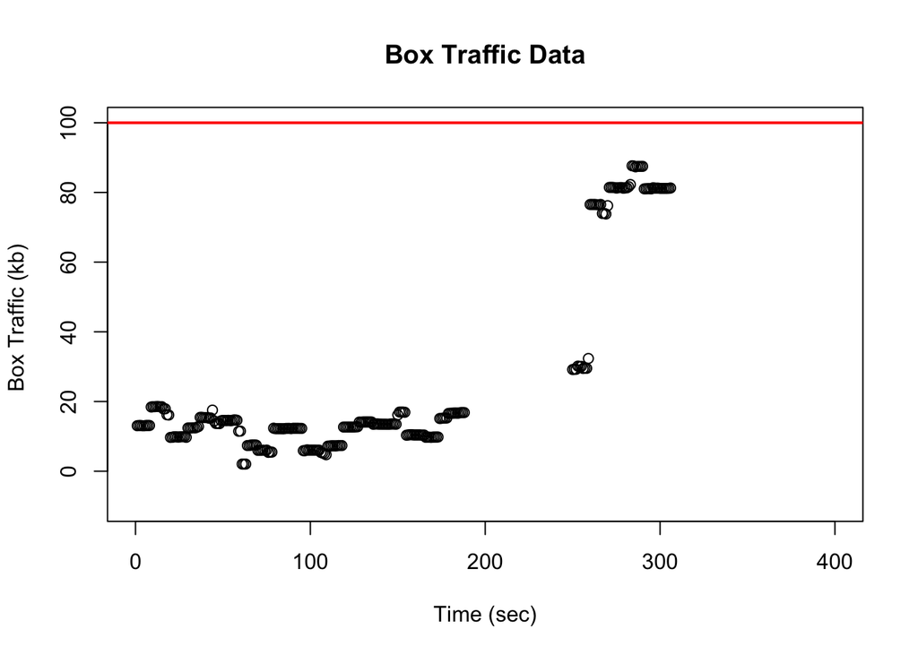

```r
maxcap=100
box_data = read.csv("out_box.csv",header=TRUE)
plot(box_data$t,box_data$y_t,ylim=c(-10,maxcap),xlim=c(0,400),
     ylab="Box Traffic (kb) ",xlab="Time (sec)",main="Box Traffic Data")
abline(h = maxcap,col="red",lwd=2)
```

## Example 3: Create Your Own Test Data!

This is a bit of Python code that will look at the total bytes received from your network. You can use this code to generate your own set of network capacity data to try it out on your own servers. The code `network_pyton.py` takes in the maximum time you want to log network data and it outputs a CSV file as “out_data.csv”; this file contains $t$ and $y_t$.

To run the code, you need Python installed. If you don’t have Python already, I suggest getting it it installed as many data science jobs will be using Python. But, if you do not want to for whatever reason, you can run the exact code on our cluster computing machines, which has Python natively installed.

```bash
# The argument 120 will indicate that it will take 120 seconds of network bytes received data. Feel free to change it as you please.
# The second argument 1 will arbitrarily corrupt your data. If you give it 0, it will give you real, uncorrupted data.

# Run this in your shell/terminal environment.
python network_python.py 120 0
```

While the code is running, I suggest opening up some videos or visiting other websites to simulate increased traffic; you should see your bytes received starting to go up as you visit more websites. You can also simulate a network outage by disconnecting your computer from the internet for a few seconds; this should either slow your traffic data or on some computers, return empty (i.e. NA) values. In any case, here is my run of this data.

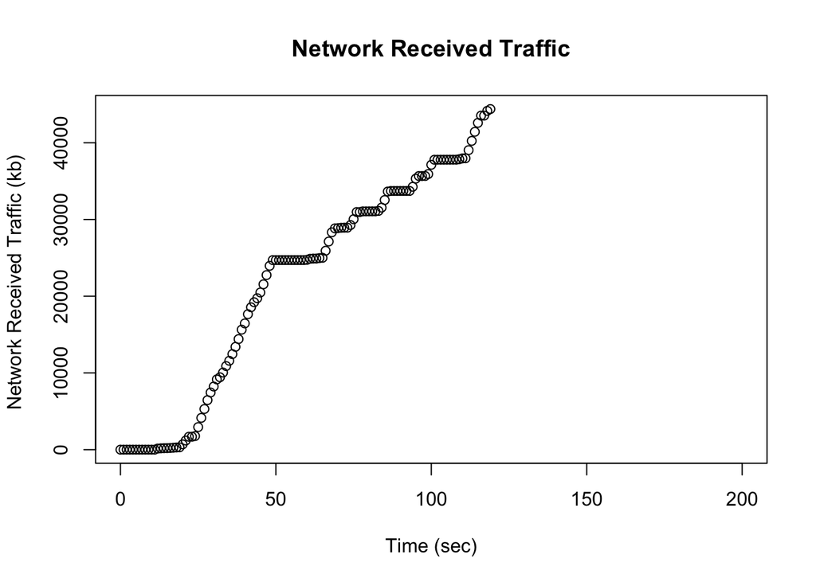

```r
network_data = read.csv("out_data.csv",header=TRUE)
plot(network_data$t,network_data$yt,xlim=c(0,200),
     ylab="Network Received Traffic (kb) ",xlab="Time (sec)",main="Network Received Traffic")
```

To test whether your algorithm is hitting the correct maxcap value, one way to do this by arbitrarily setting the maxcap to a value that you already observed.

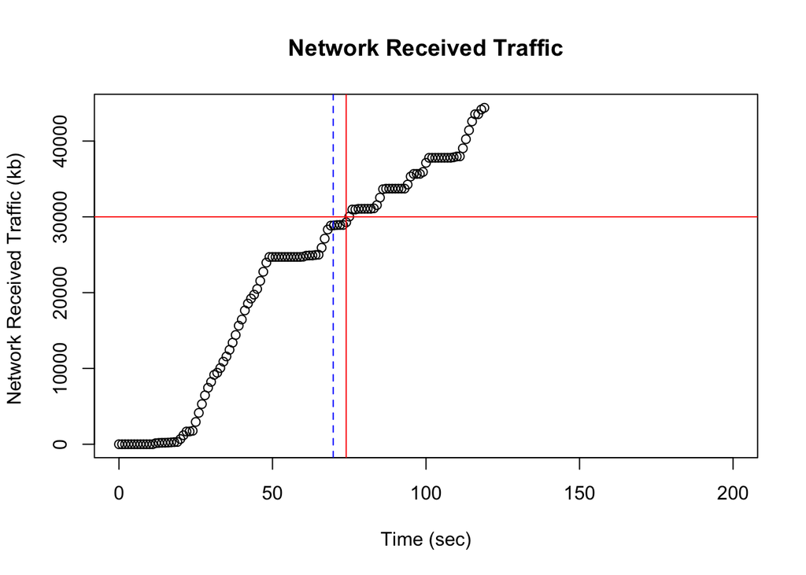

```r
# Let's simply consider a linear regression function
# without any input cleaning.
your_function <- function(y_t,t,maxcap) {
  linmodel = lm(y_t ~ t)
  int = coef(linmodel)[1]; slope = coef(linmodel)[2]
  tout = (maxcap -int)/slope - 10
  return(tout)
}

maxcap = 30000
plot(network_data$t,network_data$yt,xlim=c(0,200),
     ylab="Network Received Traffic (kb) ",xlab="Time (sec)",main="Network Received Traffic")
abline(h=maxcap,col="red",lwd=1)
mint = your_function(network_data$yt,network_data$t,maxcap)
abline(v=mint,col="blue",lty=2)
abline(v=max(network_data$t[which(network_data$yt < maxcap)]),col="red",lty=1)
```

The linear model algorithm (in blue) does a reasonably good job at hitting below the maxcap (in red). However, it may not work for all maxcap thresholds.

## Example 4: Create Your Own Test Data, Part 2

Now, let’s arbitrarily corrupt the data to simulate a potential server outage.

```bash
# The argument 60 will indicate that it will take 60 seconds of network bytes received data. Feel free to change it as you please.
# The second argument 1 will arbitrarily corrupt your data.

# Run this in your shell/terminal environment.
python network_python.py 60 1
```

Let’s plot this data in R

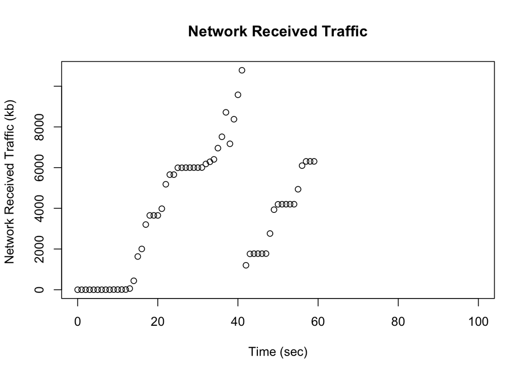

```r
network_data = read.csv("out_data_corrupt.csv",header=TRUE)
plot(network_data$t,network_data$yt,xlim=c(0,100),
     ylab="Network Received Traffic (kb) ",xlab="Time (sec)",main="Network Received Traffic")
```

This dataset is harder to predict as there are interrupted time series. For example, our linear regression model will predict a time that may be too early.

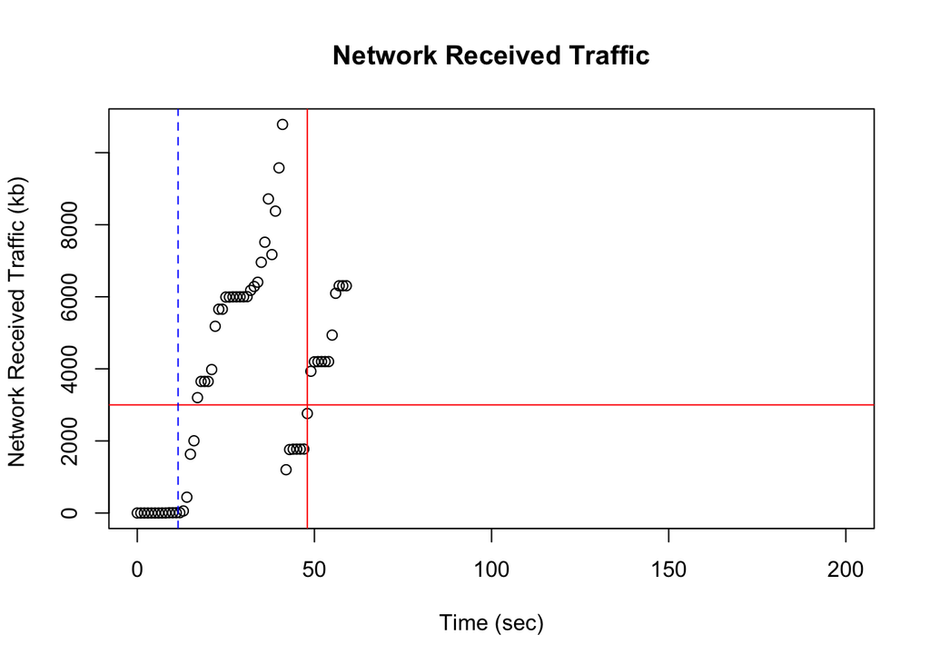

```r
maxcap = 3000
plot(network_data$t,network_data$yt,xlim=c(0,200),
     ylab="Network Received Traffic (kb) ",xlab="Time (sec)",main="Network Received Traffic")
abline(h=maxcap,col="red",lwd=1)
mint = your_function(network_data$yt,network_data$t,maxcap)
abline(v=mint,col="blue",lty=2)
abline(v=max(network_data$t[which(network_data$yt < maxcap)]),col="red",lty=1)
```